# Monte Carlo Methods

## The Law of Large Numbers

> The law of large numbers states that given a sample of independent and identically distributed values, the sample mean converges to the true mean.

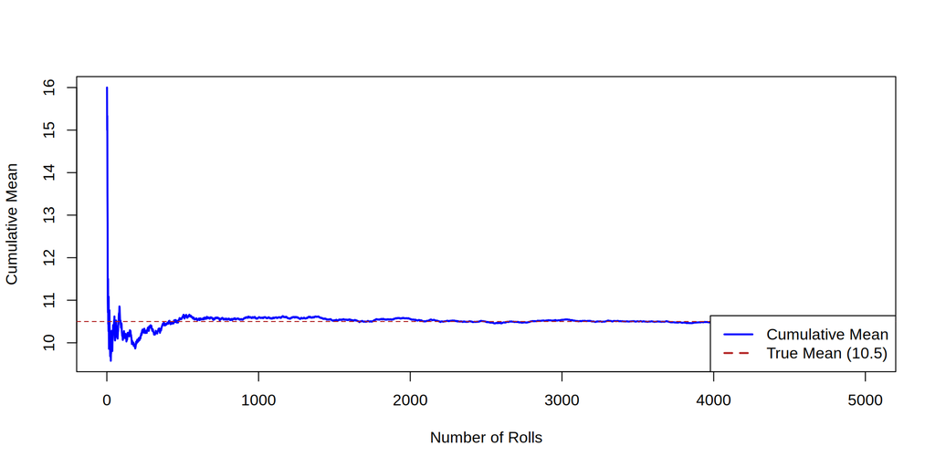

## The Law of Large Numbers

[interactive chart not shown]

## The Law of Large Numbers

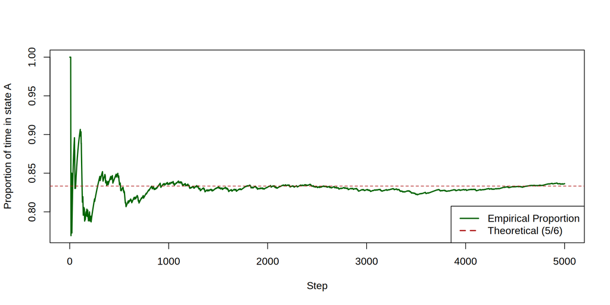

## A Brief History of Monte Carlo Methods

Monte Carlo methods were originally created by mathematician [Stanislaw Ulam](https://en.wikipedia.org/wiki/Stanis%C5%82aw_Ulam) who worked on the Manhattan project.

He wanted to know:

**How much uranium do you need to make a nuclear bomb?**

## Nuclear Fission

[figure not shown]

## Nuclear Fission

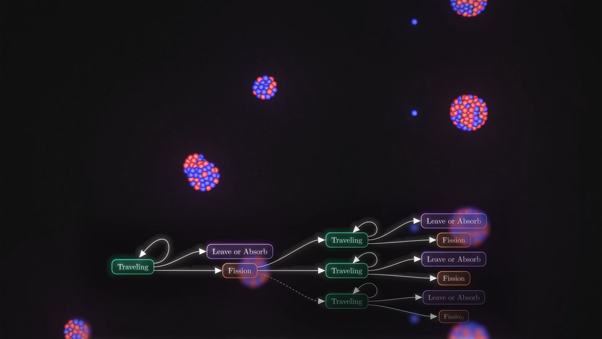

## Nuclear Fission

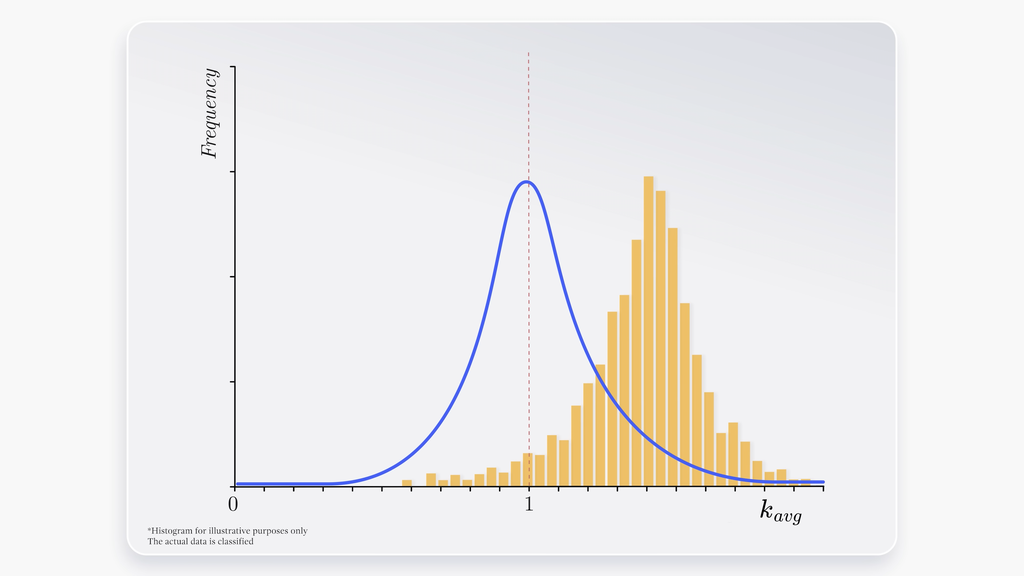

## Monte Carlo Methods

> Are a broad class of computational algorithms that rely on repeated random sampling to obtain numerical results.

**In Statistics**:

- Bayesian Inference
- Multiple Imputation
- Sample Size/Power for Complex Designs
- Bootstrapping

## Monte Carlo Methods for Probability Questions

**Monty Hall Problem**

There was a famous American game show **Let’s Make a Deal.**

> Suppose you’re on a game show, and you’re given the choice of three doors: Behind one door is a car; behind the others, goats. You pick a door, say No. 1, and the host, who knows what’s behind the doors, opens another door, say No. 3, which has a goat. He then says to you, “Do you want to pick door No. 2?” Is it to your advantage to switch your choice?

## Monte Carlo Methods for Probability Questions

```r
n_simulations = 10000

stick_wins = 0
switch_wins = 0

for (i in 1:n_simulations) {

  doors = 1:3

  car_door = sample(doors, 1)

  player_choice = sample(doors, 1)

  host_options = setdiff(doors, c(player_choice, car_door))
  if (length(host_options) > 1) {
    door_opened_by_host = sample(host_options, 1)
  } else {
    door_opened_by_host = host_options
  }

  switch_choice = setdiff(doors, c(player_choice, door_opened_by_host))

  if (player_choice == car_door) {
    stick_wins = stick_wins + 1
  }

  if (switch_choice == car_door) {
    switch_wins = switch_wins + 1
  }
}
stick_prob = stick_wins / n_simulations
switch_prob = switch_wins / n_simulations
```

## Monte Carlo Methods for Probability Questions

```
Monty Hall Problem Simulation Results
```

```
Total simulations: 10,000
```

```
Wins with 'Stick' strategy: 3378  ( 33.78 %)
```

```
Wins with 'Switch' strategy: 6622  ( 66.22 %)
```

## Monte Carlo Methods for Probability Questions

```r
n = 100000

stick_wins_prob = mean(replicate(n, sample(1:3, 1) == sample(1:3, 1)))
switch_wins_prob = mean(replicate(n, sample(1:3, 1) != sample(1:3, 1)))

stick_wins_prob
```

```
[1] 0.33379
```

```r
switch_wins_prob
```

```
[1] 0.66686
```

## Sample Size/Power for Simple Designs

It turns out we can view sample size calculation as a Monte Carlo problem. By definition, power is just the probability that we reject the null hypothesis **when it is false** - i.e. at some specified alternative.

While we can’t usually determine that probability, we can if we simulate our study over and over and over and over…

## A T-test Example

Here we are interested in the difference in mean seminars in epidemiology marks between two years.

```r
n_sim = 1000
power = numeric(n_sim)

for (i in seq_len(n_sim)) {
  group1 = rnorm(n = 10, mean = 70, sd = 15)
  group2 = rnorm(n = 10, mean = 80, sd = 15)

  power[i] = (t.test(group1, group2, var.equal = TRUE)$p.value <= 0.05) |>
    as.numeric()
}

mean(power)
```

```
[1] 0.288
```

## A T-test Example

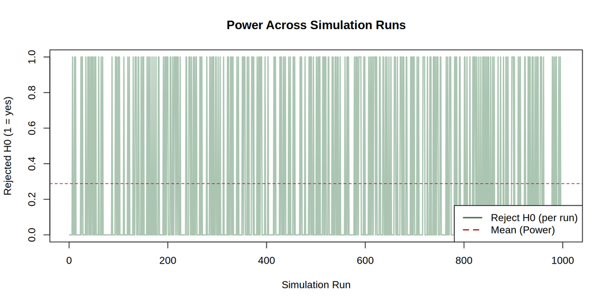

## Sample Size/Power for Complex Designs

> From Biostats I:

> $$n = \left[\frac{\left(z_{1-\alpha/2} + z_{1-\beta}\right)\sigma}{d} \right]^2$$

> (per group, the two-sample version carries an extra factor of 2)

But what happens if you have a much more complicated study design. What if you were interested in calculating the required sample size for a difference in means over time - i.e a mixed-effects model.

Often there are no sample size formulae for the study design we want.

## Sample Size/Power for Complex Designs

```r
n_sim = 1000 # number of simulations
n_per_group = 30 # subjects per group
n_time = 4 # number of time points
effect = 0.1 # true difference in slope between groups
alpha = 0.05 # significance level

sim = function(i) {
  # Simulate data
  group = rep(rep(c("A", "B"), each = n_per_group), each = n_time)
  subject = rep(1:(2 * n_per_group), each = n_time)
  time = rep(0:(n_time - 1), times = 2 * n_per_group)
  intercept = rnorm(2 * n_per_group, 0, 1)[subject]
  slope = ifelse(group == "A", 0.5, 0.5 + effect)
  y = intercept + slope * time + rnorm(length(time), 0, 1)
  dat = data.frame(
    subject = factor(subject),
    group = factor(group),
    time = time,
    y = y
  )

  # Fit mixed model
  fit = lmer(y ~ group * time + (1 | subject), data = dat)
  pval = summary(fit)$coefficients["groupB:time", "Pr(>|t|)"]

  as.numeric(pval < alpha)
}

power = foreach(x = seq_len(n_sim), .combine = c, .options.future = list(seed = TRUE)) %dofuture% sim(x)

mean(power)
```

```
[1] 0.153
```

## Sample Size/Power for Complex Designs

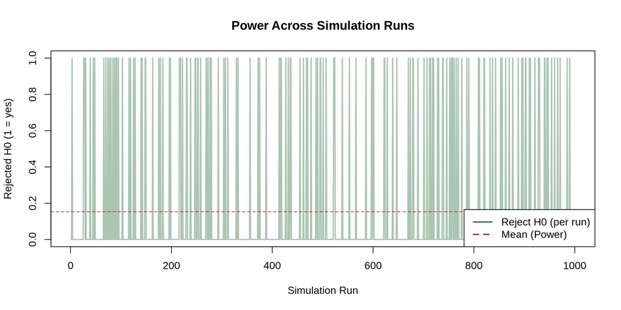

# Bootstrap

## Why Bootstrapping?

In traditional frequentist statistics we need to know the probability distribution of the **sample/test statistic** to perform an analysis. Often we use estimators that have well-defined **asymptotic** characteristics.

However, the appropriateness of these parametric approaches depends on a set of assumptions that may not always be met, often by invoking the Central Limit Theorem (Conditional Normality, Homoscedasticity, etc…).

## Why Bootstrapping?

But what do we do when:

- The assumptions are violated
- There is no closed-form solution to our problem.
  - What is the variance of a median?

## The Variance of a Median

For the **mean** everything is easy. We have a closed-form variance, $Var(\bar{X}) = \sigma^2/n$, and we can estimate it directly from the sample with $s^2/n$.

For the **median** the asymptotic theory gives us

$$\sqrt{n}\left(\hat{m}_n - m\right) \overset{d}{\to} N\left(0, \frac{1}{4f(m)^2}\right)
\quad \Longrightarrow \quad
Var(\hat{m}_n) \approx \frac{1}{4nf(m)^2}$$

## The Variance of a Median

The median is a **non-smooth** functional of the data.

If we *had* the population, we could just repeat the study:

```r
set.seed(123)
n = 25
n_sim = 10000

# Repeat the study 10 000 times: only possible if we know the population
medians = replicate(n_sim, median(rexp(n, rate = 1)))

# Monte Carlo "truth" vs the asymptotic formula (m = log(2) for Exp(1))
c(monte_carlo = sd(medians), asymptotic = 1 / (2 * sqrt(n) * dexp(log(2))))
```

```
monte_carlo  asymptotic
  0.2004614   0.2000000
```

Both versions need the **population** to be calculated. However, in practice we just have **one sample**.

That is where Bootstrapping comes in, we attempt to “approximate” the population, with our single sample.

## Bootstrapping in a Nutshell

The name **bootstrapping** comes from the impossible idea of pulling yourself up by your own bootstraps. We pretend our single sample is a perfect representation of the entire population. We then use this sample to simulate what would happen if we could repeat our study over and over again.

Conceptually, the thing that allows us to make many statements in statistics with some degree of certainty is the behaviour of our **sample/test statistic**.

Bootstrapping allows us to **approximate the sampling distribution** with just our sample.

**Bootstrap Distribution** $\approx$ **True Sampling Distribution**

## Bootstrapping in a Nutshell

- **Start with Your Sample**
- **Resample with Replacement**: Create a new **bootstrap sample** of the same size by drawing observations from your original sample with replacement.
- **Calculate Your Statistic**: Calculate the statistic of interest (e.g., the median) on this new bootstrap sample. Record it.
- **Repeat, Repeat, Repeat**: Repeat steps 2 and 3 a large number of times (typically 1,000 to 10,000 times).
- **Build the Bootstrap Distribution**: You now have the **bootstrap distribution** of your calculated statistic.

## Bootstrapping in a Nutshell

[figure not shown]

## Bootstrapping in a Nutshell

**Bootstrap Variance Estimator**

1. Draw a bootstrap sample $X_{1}^*, \dots,X_{n}^* \sim P_n$. Compute $\hat{\theta}_{n}^* = g\left(X_{1}^*, \dots,X_{n}^*\right)$
2. Repeat the previous step, B times, yielding estimators $\hat{\theta}_{n,1}^*, \dots,\hat{\theta}_{n,B}^*$
3. Compute:
   $$\hat{s} = \sqrt{\frac{1}{B}\sum_{j = 1}^B \left(\hat{\theta}_{n,j}^* - \bar{\theta}\right)^2}
   \quad \text{where} \quad
   \bar{\theta} = \frac{1}{B}\sum_{j = 1}^B \hat{\theta}_{n,j}^*$$
4. Output $\hat{s}$

Under appropriate regularity conditions, $\frac{\hat{s}^2}{Var(\hat{\theta}_n)} \overset{P}{\to} 1$ as $n \to \infty$

## Bootstrapping in a Nutshell

**Bootstrap Confidence Interval**

1. Draw a bootstrap sample $X_{1}^*, \dots,X_{n}^* \sim P_n$. Compute $\hat{\theta}_{n}^* = g\left(X_{1}^*, \dots,X_{n}^*\right)$
2. Repeat the previous step, B times, yielding estimators $\hat{\theta}_{n,1}^*, \dots,\hat{\theta}_{n,B}^*$
3. Let
   $$\hat{F}(t) = \frac{1}{B}\sum_{j = 1}^BI\left(\sqrt{n}(\hat{\theta}_{n,j}^* - \hat{\theta}_n) \le t\right)$$
4. Let
   $$C_n = \left[\hat{\theta}_n - \frac{t_{1 - \alpha/2}}{\sqrt{n}}, \hat{\theta}_n - \frac{t_{\alpha/2}}{\sqrt{n}}\right]$$
   where $t_{\alpha/2} = \hat{F}^{-1}(\alpha/2)$ and $t_{1 - \alpha/2} = \hat{F}^{-1}(1 - \alpha/2)$
5. Output $C_n$

## A Quick Example

Thankfully, R makes it easy for us to bootstrap.

```r
median = function(data, boot, col) {

  data = data[boot, col]

  quantile(data, probs = 0.5, type = 7)

}

boot_median = boot(
  data = mtcars, statistic = median,
  R = 1000, col = "wt"
)
```

```
ORDINARY NONPARAMETRIC BOOTSTRAP


Call:
boot(data = mtcars, statistic = median, R = 1000, col = "wt")


Bootstrap Statistics :
    original     bias    std. error
t1*    3.325 -0.0343975   0.1779596
```

## A Quick Example

Getting the confidence intervals is just as easy.

```r
boot_median |>
  boot.ci(
    type = c(
      "norm", "basic",
      "perc", "bca"
    )
  )
```

```
BOOTSTRAP CONFIDENCE INTERVAL CALCULATIONS
Based on 1000 bootstrap replicates

CALL :
boot.ci(boot.out = boot_median, type = c("norm", "basic", "perc",
    "bca"))

Intervals :
Level      Normal              Basic
95%   ( 3.011,  3.708 )   ( 3.145,  3.828 )

Level     Percentile            BCa
95%   ( 2.822,  3.505 )   ( 2.780,  3.490 )
Calculations and Intervals on Original Scale
```

## Bootstrap Regression

Everything we’ve discussed so far can be naturally extended for use with any form of regression.

For bootstrapping regression there are generally two approaches:

1. Treat the predictors $X$ as **random** - resample whole cases (rows).
2. Treat the predictors $X$ as **fixed** - hold $X$ at its observed values and resample the **residuals**.

## Bootstrap Regression (Random)

This is conceptually just a regular bootstrap, as we have discussed.

**Note**

1. Draw a bootstrap sample $X_{1}^*, \dots,X_{n}^* \sim P_n$. Perform your chosen regression.
2. Repeat the previous step, B times, yielding estimators $\hat{\theta}_{n,1}^*, \dots,\hat{\theta}_{n,B}^*$
3. Compute and output whatever statistic you are interested in (mean, CI, variance, etc)

## Bootstrap Regression (Fixed)

1. Estimate the regression coefficients $A, B_1, \dots, B_k$ on the original sample, and calculate the **fitted value** and **residual** for each observation:
   $$\hat{Y}_i = A + B_1x_{i1} + \dots + B_kx_{ik}
   \qquad
   E_i = Y_i - \hat{Y}_i$$
2. Select bootstrap samples of the **residuals**, $e_b^* = \left[E_{b1}^*, \dots, E_{bn}^*\right]$, and add them back to the fitted values to get bootstrapped outcomes:
   $$Y_{bi}^* = \hat{Y}_i + E_{bi}^*$$
3. Regress the bootstrapped $Y_b^*$ values on the **fixed** $X$ values to obtain bootstrap regression coefficients.
4. The bootstrapped regression coefficients can be used in the usual manner to construct bootstrap standard errors and confidence intervals for the regression coefficients.

## A Regression Example

R makes bootstrapping particularly easy by providing the `boot` and `boot.ci` functions, these functions do most of the bootstrapping work for us.

Here we will perform a simple regression on the `iris` dataset, to calculate the confidence interval for the `Species` coefficients.

## A Regression Example

First we have to create a bootstrap function that **returns the estimate we are interested in**.

Note: the data and boot arguments are **required**, you can have any number of additional arguments, but the first arguments must be the data and a bootstrap index indicator.

```r
boot_function = function(data, boot) {
  data = data[boot, ]

  # out = lm(Sepal.Length ~ Species, data = data[boot, ])
  out = lm(Sepal.Length ~ Species, data = data)

  coefficients(summary(out))["Speciesversicolor", "Estimate"]
}
```

## A Regression Example

```r
# data = data
# statistic = the function that calculates the statistic you want
# R = number of bootstrap replicates, should ideally be >= 2000
# and most commonly >= 10 000 is used
boot_out = boot(data = iris, statistic = boot_function, R = 100)

boot_out
```

```
ORDINARY NONPARAMETRIC BOOTSTRAP


Call:
boot(data = iris, statistic = boot_function, R = 100)


Bootstrap Statistics :
    original     bias    std. error
t1*     0.93 0.01278814  0.08086877
```

## A Regression Example

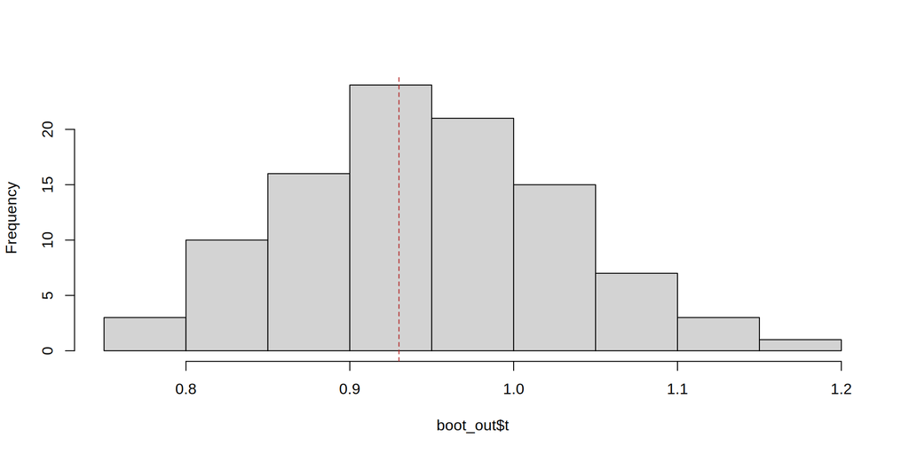

```r
boot_out$t |>
  hist(main = "")
abline(v = boot_out$t0, lty = 2, col = "#b22222")
```

## A Regression Example

```r
# type = "all" gives 4 of the 5 intervals: the studentized interval needs
# a variance estimate for each replicate, which we did not supply.
boot_out |>
  boot.ci(type = "all")
```

```
BOOTSTRAP CONFIDENCE INTERVAL CALCULATIONS
Based on 100 bootstrap replicates

CALL :
boot.ci(boot.out = boot_out, type = "all")

Intervals :
Level      Normal              Basic
95%   ( 0.7587,  1.0757 )   ( 0.7358,  1.0636 )

Level     Percentile            BCa
95%   ( 0.7964,  1.1242 )   ( 0.7827,  1.0923 )
Calculations and Intervals on Original Scale
Some basic intervals may be unstable
Some percentile intervals may be unstable
Some BCa intervals may be unstable
```

## A Regression Example

```r
log = log
inv_log = function(x) exp(1)^x

boot_out |>
  boot.ci(type = "all", h = log, hinv = inv_log)
```

```
BOOTSTRAP CONFIDENCE INTERVAL CALCULATIONS
Based on 100 bootstrap replicates

CALL :
boot.ci(boot.out = boot_out, type = "all", h = log, hinv = inv_log)

Intervals :
Level      Normal              Basic
95%   ( 0.7785,  1.0889 )   ( 0.7694,  1.0860 )

Level     Percentile            BCa
95%   ( 0.7964,  1.1242 )   ( 0.7827,  1.0923 )
Calculations on Transformed Scale;  Intervals on Original Scale
Some basic intervals may be unstable
Some percentile intervals may be unstable
Some BCa intervals may be unstable
```

## Bootstrap Still has Assumptions

1. **Representative Sample**: The original sample must be representative of the population of interest. Since bootstrap treats the sample as a proxy for the true population, any bias in the original sample will be propagated through the bootstrap process.
2. **Independence**: Observations in the original sample should be independent of each other (or appropriately structured for dependent data).
3. **Adequate Sample Size**: The sample size should be large enough for the bootstrap distribution to approximate the true sampling distribution well. **Very small samples may not provide reliable bootstrap estimates.**

## When Bootstrap May Fail

1. The sample is too small.
2. The statistic of interest is not **smooth** (e.g., the sample maximum or minimum). Note the median is fine here technically it is non-smooth, but the bootstrap is still consistent for it.
3. There are strong dependencies not accounted for in the resampling scheme.
4. The original sample is heavily biased or unrepresentative.

## A Correlated Bootstrap Example

2. **Independence**: Observations in the original sample should be independent of each other (or appropriately structured for dependent data).

This means that as long as we take into account the dependence structure of our data, we can still use bootstrapping.

In the case of correlated or longitudinal data, what this means is that we don’t resample individual rows, instead we **resample individuals** (and all their associated rows in the dataset.)

## A Correlated Bootstrap Example

```r
# the dataset we will be using
sleepstudy |>
  head(n = 10)
```

```
   Reaction Days Subject
1  249.5600    0     308
2  258.7047    1     308
3  250.8006    2     308
4  321.4398    3     308
5  356.8519    4     308
6  414.6901    5     308
7  382.2038    6     308
8  290.1486    7     308
9  430.5853    8     308
10 466.3535    9     308
```

## A Correlated Bootstrap Example

```r
boot_function = function(data, boot) {

  resampled_id = data[boot]

  # A subject can be drawn more than once. Each draw must get a NEW id,
  # otherwise lmer treats the copies as the same cluster.
  boot_data = do.call(rbind, Map(function(id, draw) {
    rows = sleepstudy[sleepstudy$Subject == id, ]
    rows$Subject = factor(paste0(id, "_", draw))
    rows
  }, resampled_id, seq_along(resampled_id)))

  out = lmer(Reaction ~ Days + (1 | Subject), data = boot_data)

  coefficients(summary(out))["Days", "Estimate"]
}
```

## A Correlated Bootstrap Example

```r
# data = data
# statistic = the function that calculates the statistic you want
# R = number of bootstrap replicates, should ideally be >= 2000
# and most commonly >= 10 000 is used
ids = unique(sleepstudy$Subject)

boot_out = boot(data = ids, statistic = boot_function, R = 100)

boot_out
```

```
ORDINARY NONPARAMETRIC BOOTSTRAP


Call:
boot(data = ids, statistic = boot_function, R = 100)


Bootstrap Statistics :
    original     bias    std. error
t1* 10.46729 0.03374783     1.34456
```

## Additional Resources

Very good introduction to theoretical fundamentals of bootstrapping: https://www.stat.cmu.edu/~larry/=sml/Boot.pdf